# Project

Analysis of Housing Prices

Questions of Interest:

Does lotsize have a significant effect on housing price. We suspect it does, and if that’s true we’d like to know if any other predictors such as: the number of bathrooms, stories, and availability of air conditioning.

Regression Method:

Plot Housing prices against lotsize and use an information criterion (AIC) to help determine which other predictors are useful to our model.

```r
library(Ecdat)
library(MASS)
```

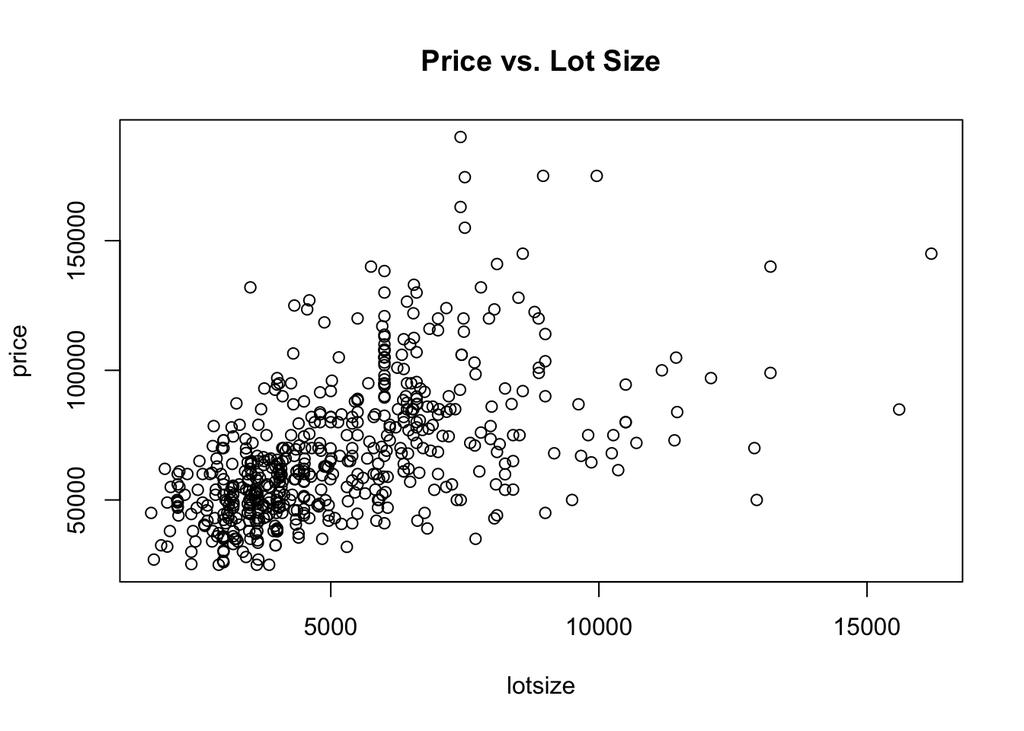

```r
data("Housing")

df<-Housing
df$bedrooms=as.factor(df$bedrooms)
df$bathrms=as.factor(df$bathrms)
df$stories=as.factor(df$stories)
df$driveway=as.factor(df$driveway)
df$recroom=as.factor(df$recroom)
df$fullbase=as.factor(df$fullbase)
df$gashw=as.factor(df$gashw)
df$airco=as.factor(df$airco)
df$garagepl=as.factor(df$garagepl)
df$prefarea=as.factor(df$prefarea)
attach(df)


plot(lotsize,price, main= "Price vs. Lot Size")
```

```r
fit<-lm(price~lotsize)
```

Plotting the Residual vs. Fitted scatter plot:

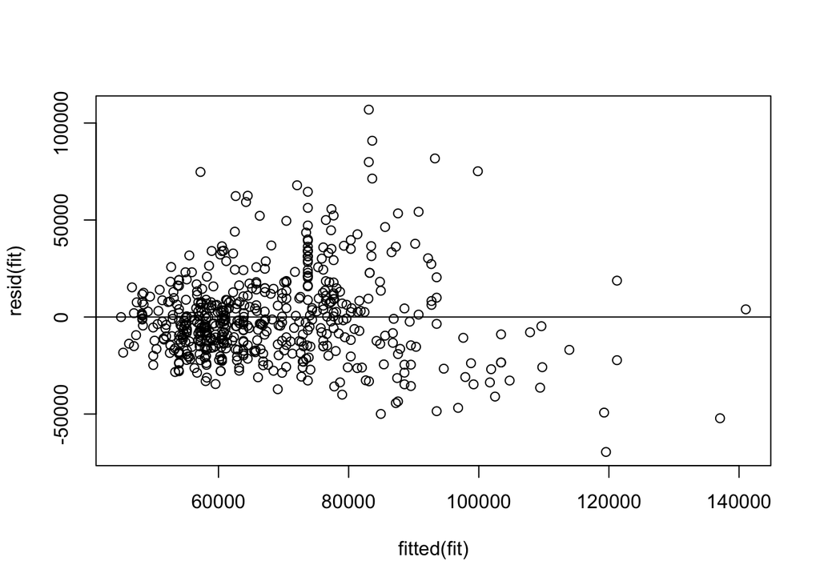

```r
plot(fitted(fit),resid(fit))
abline(0,0)
```

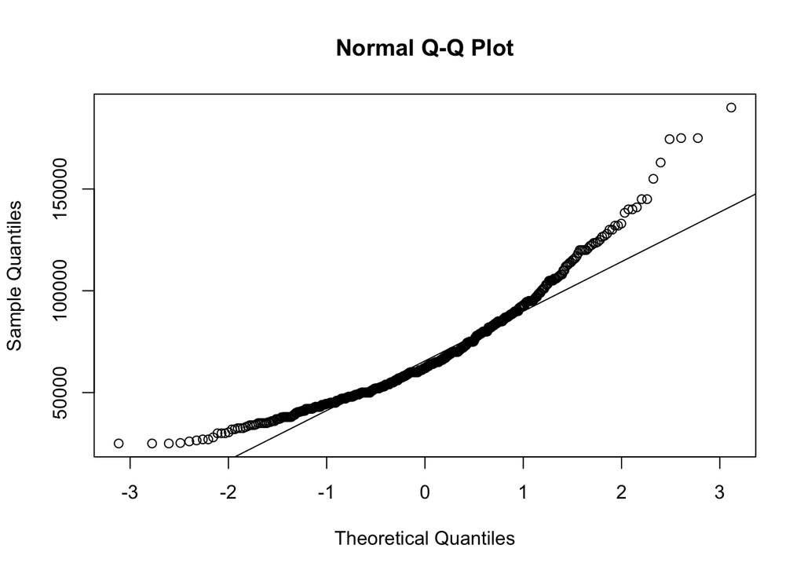

```r
qqnorm(price)
qqline(price)
```

The Residual plot shows some slight fanning, indicating a break in LINE conditions. Unequal variance is likely present. The Normal Q-Q Plot is obviously non linear and breaks normality condition. We will use the box cox method to find a suitable transformation on our response.

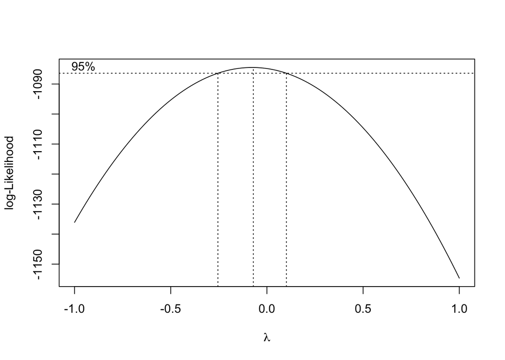

```r
bc<-boxcox(fit,lambda=seq(-1,1),length=10)
```

```r
estimate<-bc$x[which.max(bc$y)]
estimate
```

```
## [1] -0.07070707
```

After applying the box cox method, we chose a log function to transform our response data. Now we plot the residuals of the transformed linear model.

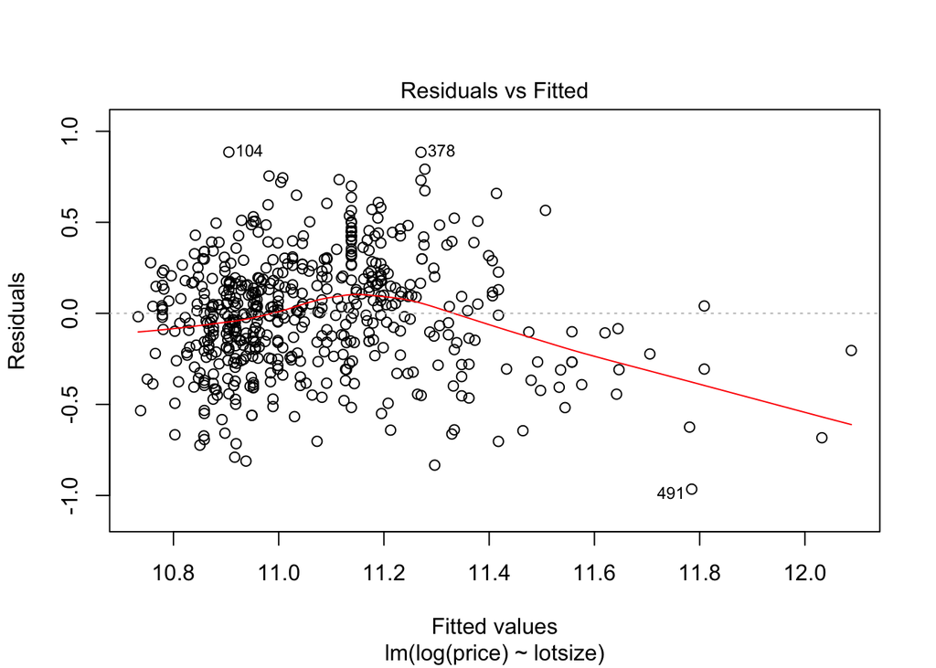

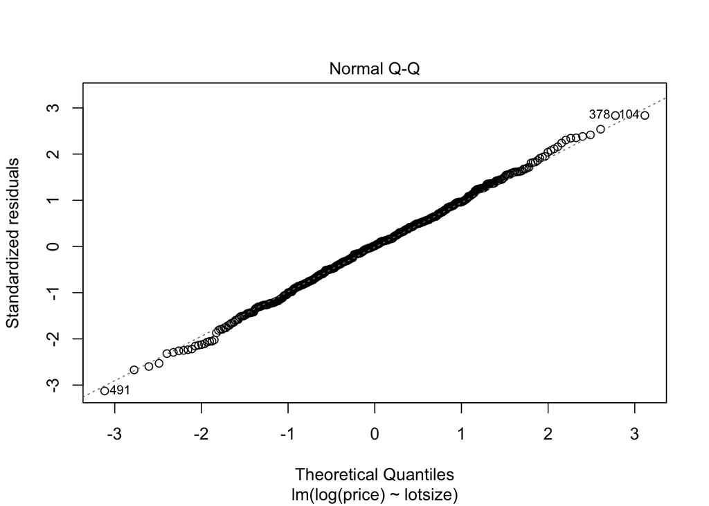

```r
fit.trans<-lm(log(price)~lotsize)
plot(fit.trans,c(1,2))
```

The transformed residual plot has a horizontal band around the 0 line, with no discernable pattern in the plot. High predictor values trend to lower residual values, but are relatively normal. Thus we satisfy the Linearity and Equal Variane LINE conditions.

The transformed Q-Q plot is linear and satisfies our Normality LINE condition.

Now we will check the independence of our transformed data by plotting residuals vs. order.

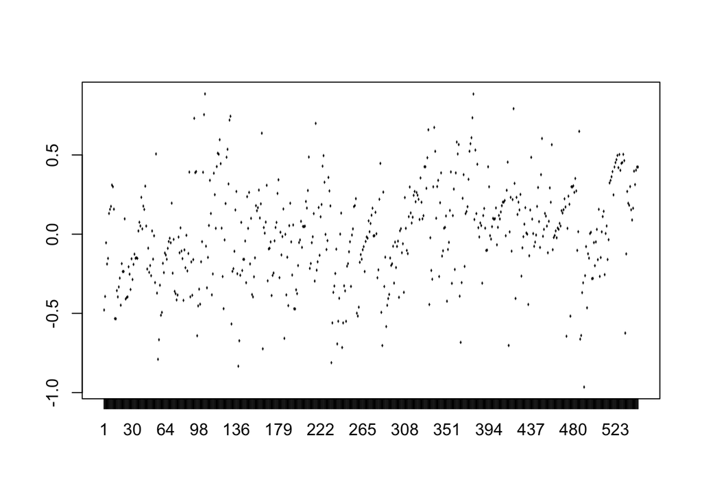

```r
order<-as.factor(c(1:546))
plot(order,resid(fit.trans))
```

Now we will conduct a t test to determine if we should reject or accept our null hypothesis. Our hypothesis is stated below.

$H_{0}$: $\beta_{1}$=0

$H_{1}$: $\beta_{1}$=/=0

```r
summary(fit.trans)
```

```
##
## Call:
## lm(formula = log(price) ~ lotsize)
##
## Residuals:
##      Min       1Q   Median       3Q      Max
## -0.96513 -0.20552  0.00396  0.19758  0.88531
##
## Coefficients:
##              Estimate Std. Error t value Pr(>|t|)
## (Intercept) 1.058e+01  3.451e-02  306.51   <2e-16 ***
## lotsize     9.315e-05  6.177e-06   15.08   <2e-16 ***
## ---
## Signif. codes:  0 '***' 0.001 '**' 0.01 '*' 0.05 '.' 0.1 ' ' 1
##
## Residual standard error: 0.3127 on 544 degrees of freedom
## Multiple R-squared:  0.2947, Adjusted R-squared:  0.2935
## F-statistic: 227.4 on 1 and 544 DF,  p-value: < 2.2e-16
```

We get a student t value of 15.08, with p value < 2e-16. Which is < $\alpha$ = 0.05. This allows us to reject the null hypothesis and assume lotsize has a significant effect on our response, price.

Regression Analysis, Building Our Model: Using a scatterplot matrix we will look for the correlation between price and lotsize. Lotsize is the only numeric predictor, which is why we run a correlation matrix on it.

```r
library("PerformanceAnalytics")
```

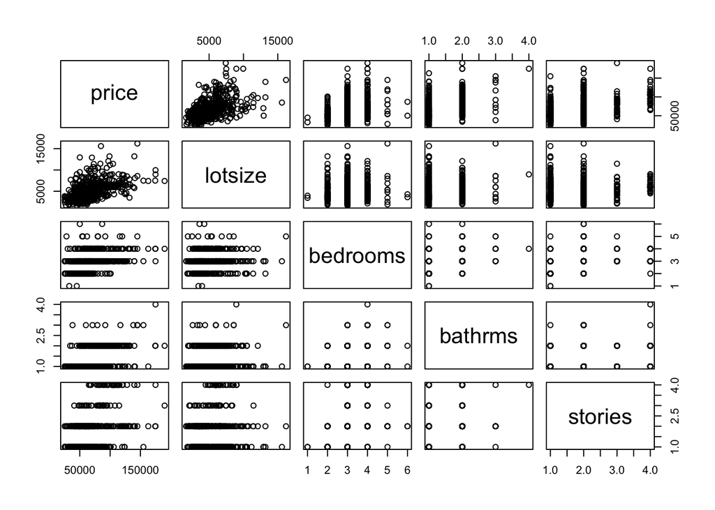

```r
fit.full<-lm(price~lotsize+bedrooms+bathrms+stories+driveway+recroom+fullbase+gashw+airco+garagepl+prefarea)
pairs(price~lotsize+bedrooms+bathrms+stories)
```

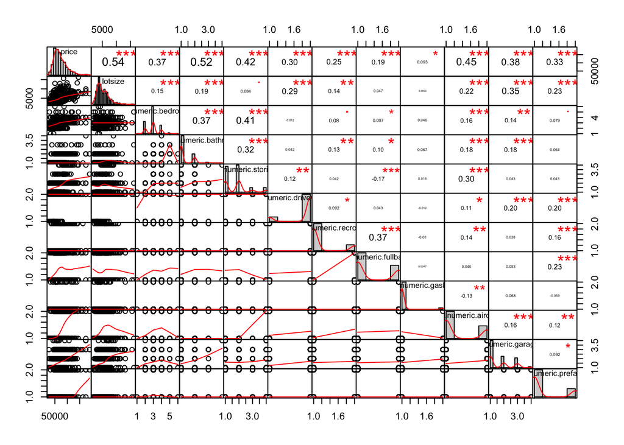

```r
df2<-data.frame(price,lotsize,as.numeric(bedrooms),as.numeric(bathrms),as.numeric(stories),as.numeric(driveway),as.numeric(recroom),as.numeric(fullbase),as.numeric(gashw),as.numeric(airco),as.numeric(garagepl),as.numeric(prefarea))

chart.Correlation(df2, histogram=TRUE, pch=19)
```

Using the Akaike Information Criterion we will select the final predictors for the model.

```r
#fit.red = lm(price~1)
#fit.full = lm(price~lotsize+bedrooms+bathrms+stories+driveway+recroom+fullbase+gashw+airco+garagepl+prefarea)
#step(fit.red, scope = list(lower=fit.red, upper=fit.full))

mod0<-lm(price~1)
add1(mod0,~.+lotsize+bedrooms+bathrms+stories+driveway+recroom+fullbase+gashw+airco+garagepl+prefarea,test="F")
```

```
## Single term additions
##
## Model:
## price ~ 1
##          Df  Sum of Sq        RSS   AIC  F value    Pr(>F)
## <none>                 3.8860e+11 11131
## lotsize   1 1.1156e+11 2.7704e+11 10948 219.0558 < 2.2e-16 ***
## bedrooms  5 5.9931e+10 3.2867e+11 11050  19.6931 < 2.2e-16 ***
## bathrms   3 1.0618e+11 2.8242e+11 10963  67.9235 < 2.2e-16 ***
## stories   3 7.3256e+10 3.1535e+11 11023  41.9697 < 2.2e-16 ***
## driveway  1 3.4317e+10 3.5429e+11 11083  52.6928 1.354e-12 ***
## recroom   1 2.5261e+10 3.6334e+11 11096  37.8209 1.503e-09 ***
## fullbase  1 1.3476e+10 3.7513e+11 11114  19.5420 1.189e-05 ***
## gashw     1 3.3492e+09 3.8525e+11 11128   4.7293   0.03008 *
## airco     1 7.9867e+10 3.0874e+11 11008 140.7273 < 2.2e-16 ***
## garagepl  3 5.9648e+10 3.2895e+11 11046  32.7598 < 2.2e-16 ***
## prefarea  1 4.2082e+10 3.4652e+11 11071  66.0637 2.959e-15 ***
## ---
## Signif. codes:  0 '***' 0.001 '**' 0.01 '*' 0.05 '.' 0.1 ' ' 1
```

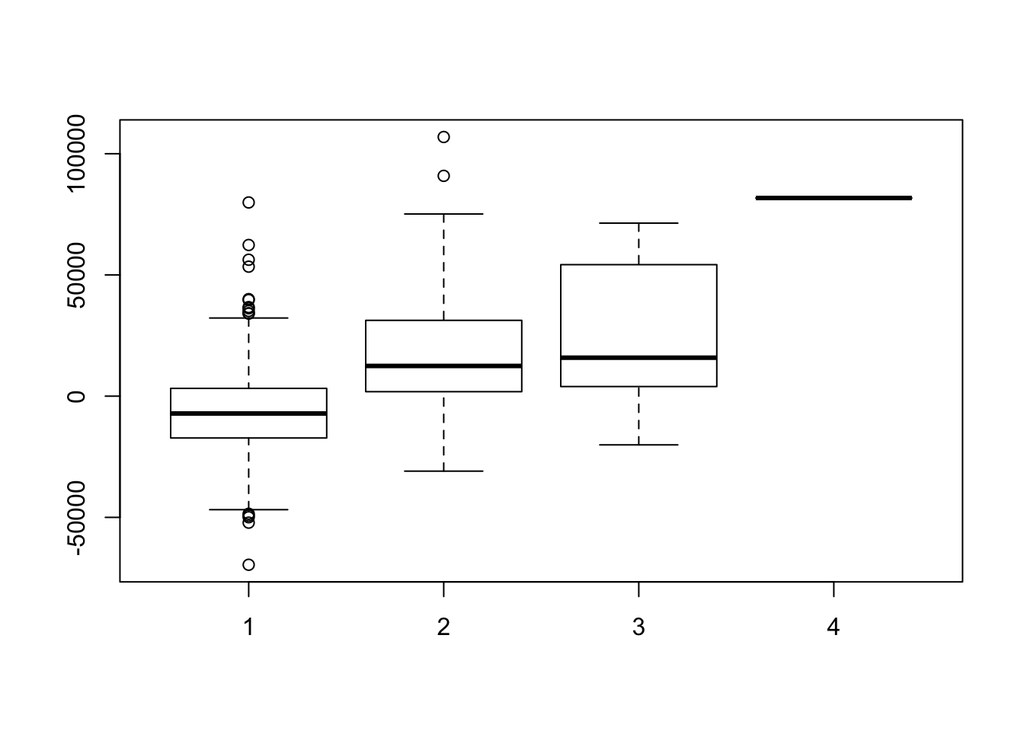

```r
mod1=update(mod0,~.+lotsize)
plot(bathrms,resid(mod1))
```

```r
add1(mod1,~.+bedrooms+bathrms+stories+driveway+recroom+fullbase+gashw+airco+garagepl+prefarea,test="F")
```

```
## Single term additions
##
## Model:
## price ~ lotsize
##          Df  Sum of Sq        RSS   AIC  F value    Pr(>F)
## <none>                 2.7704e+11 10948
## bedrooms  5 3.7550e+10 2.3949e+11 10879  16.9019 1.554e-15 ***
## bathrms   3 7.0971e+10 2.0607e+11 10793  62.1068 < 2.2e-16 ***
## stories   3 5.5593e+10 2.2145e+11 10832  45.2708 < 2.2e-16 ***
## driveway  1 8.6019e+09 2.6844e+11 10933  17.3997 3.526e-05 ***
## recroom   1 1.2811e+10 2.6423e+11 10925  26.3272 4.019e-07 ***
## fullbase  1 1.0067e+10 2.6698e+11 10930  20.4761 7.423e-06 ***
## gashw     1 3.7147e+09 2.7333e+11 10943   7.3796  0.006807 **
## airco     1 4.5737e+10 2.3131e+11 10852 107.3688 < 2.2e-16 ***
## garagepl  3 1.8860e+10 2.5818e+11 10916  13.1732 2.592e-08 ***
## prefarea  1 1.6995e+10 2.6005e+11 10916  35.4863 4.620e-09 ***
## ---
## Signif. codes:  0 '***' 0.001 '**' 0.01 '*' 0.05 '.' 0.1 ' ' 1
```

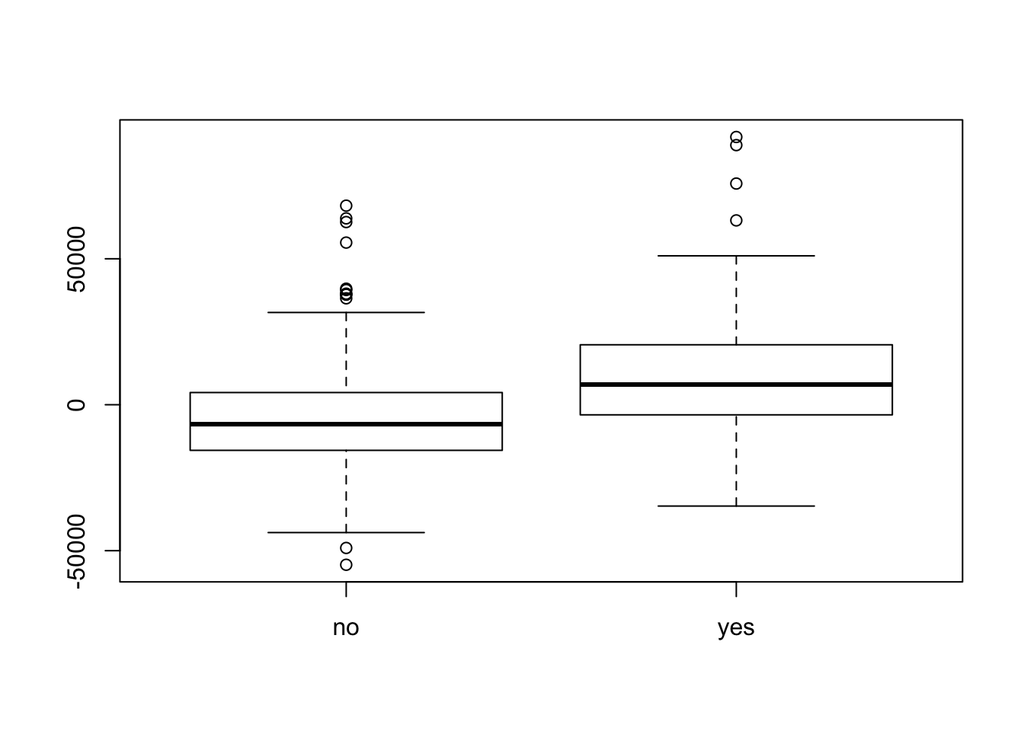

```r
mod2=update(mod1,~.+bathrms)
plot(airco,resid(mod2))
```

```r
add1(mod2,~.+bedrooms+stories+driveway+recroom+fullbase+gashw+airco+garagepl+prefarea,test="F")
```

```
## Single term additions
##
## Model:
## price ~ lotsize + bathrms
##          Df  Sum of Sq        RSS   AIC F value    Pr(>F)
## <none>                 2.0607e+11 10793
## bedrooms  5 1.3933e+10 1.9214e+11 10765  7.7735 4.483e-07 ***
## stories   3 2.4595e+10 1.8148e+11 10730 24.3044 9.207e-15 ***
## driveway  1 8.9773e+09 1.9710e+11 10771 24.5960 9.484e-07 ***
## recroom   1 7.6044e+09 1.9847e+11 10774 20.6903 6.672e-06 ***
## fullbase  1 5.8742e+09 2.0020e+11 10779 15.8447 7.816e-05 ***
## gashw     1 1.8697e+09 2.0420e+11 10790  4.9444   0.02659 *
## airco     1 2.9825e+10 1.7625e+11 10710 91.3786 < 2.2e-16 ***
## garagepl  3 1.1809e+10 1.9426e+11 10767 10.9010 5.832e-07 ***
## prefarea  1 1.5527e+10 1.9055e+11 10752 44.0026 7.980e-11 ***
## ---
## Signif. codes:  0 '***' 0.001 '**' 0.01 '*' 0.05 '.' 0.1 ' ' 1
```

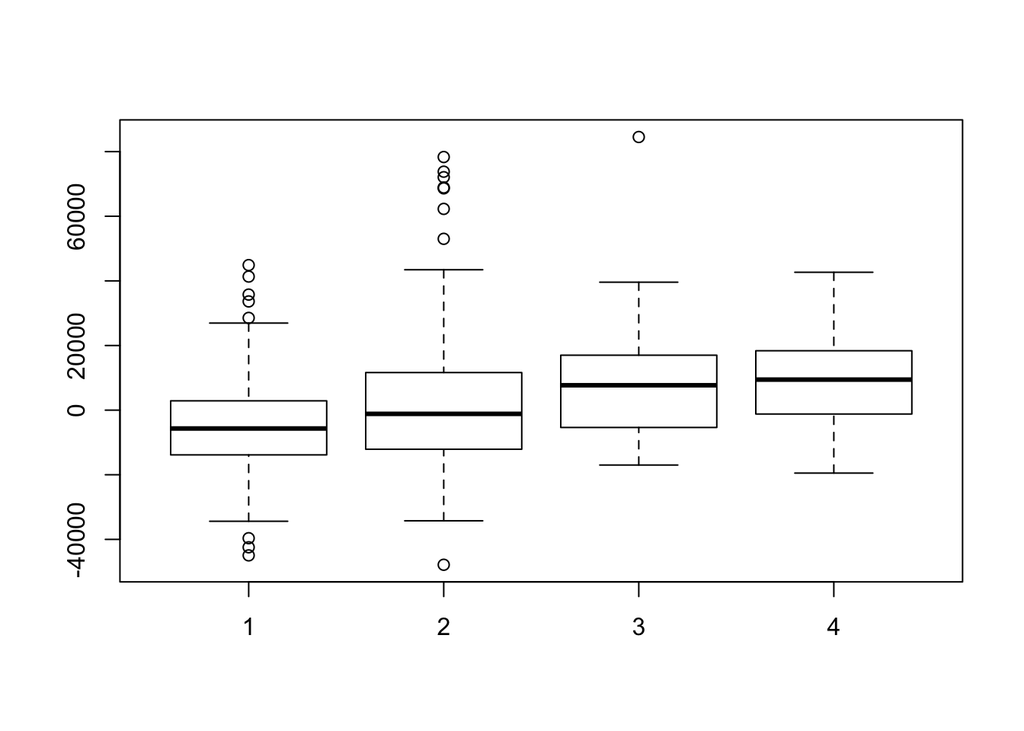

```r
mod3=update(mod2,~.+airco)
plot(stories,resid(mod3))
```

```r
anova(mod3)
```

```
## Analysis of Variance Table
##
## Response: price
##            Df     Sum Sq    Mean Sq F value    Pr(>F)
## lotsize     1 1.1156e+11 1.1156e+11 341.802 < 2.2e-16 ***
## bathrms     3 7.0971e+10 2.3657e+10  72.482 < 2.2e-16 ***
## airco       1 2.9825e+10 2.9825e+10  91.379 < 2.2e-16 ***
## Residuals 540 1.7625e+11 3.2638e+08
## ---
## Signif. codes:  0 '***' 0.001 '**' 0.01 '*' 0.05 '.' 0.1 ' ' 1
```

Research Question: Is a model containing at least one of our predictors from the dataset useful in predicting the price of a property.

Yes. To test this we conduct the following hypothesis test:

$\beta_{lotsize}$ = $\beta_{bathrms}$ = $\beta_{airco}$ = 0 vs. At least one $\beta_{k}$ $\neq$ 0

We conduct the test with a general F-test. Our full model is $Y_{i}$ = $\beta_{0}$ + $\beta_{lotsize}x_{i,lotsize}$ + $\beta_{bathrms}x_{i,bathrms}$ + $\beta_{airco}x_{i,airco}$ and the reduced model is $Y_{i}$ = $\beta_{0}$ + $\epsilon_{i}$.

```r
fit.red<-lm(price~1)
fit.full<-mod3
anova(fit.red,fit.full)
```

```
## Analysis of Variance Table
##
## Model 1: price ~ 1
## Model 2: price ~ lotsize + bathrms + airco
##   Res.Df        RSS Df  Sum of Sq      F    Pr(>F)
## 1    545 3.8860e+11
## 2    540 1.7625e+11  5 2.1235e+11 130.13 < 2.2e-16 ***
## ---
## Signif. codes:  0 '***' 0.001 '**' 0.01 '*' 0.05 '.' 0.1 ' ' 1
```

The F value is 130.13, with a p values < 2.2e-16, which is lower than $alpha$ = 0.05. Thus we reject the null hypothesis, and conclude at least one predictor from our full model is useful in predicting price.

Research Question: Is a reduced version of our full model (including lotsize, bathrooms, and air conditioning) sufficient in estimating price?

Hypothesis:

$H_{1}$: The full model, price = lotsize + bathrooms + airconditioning

1. $H_{0}$: The reduced model, price = lotsize + bathrooms.

```r
fit.red.x1x2<-lm(price~lotsize+bathrms)
anova(fit.red.x1x2,fit.full)
```

```
## Analysis of Variance Table
##
## Model 1: price ~ lotsize + bathrms
## Model 2: price ~ lotsize + bathrms + airco
##   Res.Df        RSS Df  Sum of Sq      F    Pr(>F)
## 1    541 2.0607e+11
## 2    540 1.7625e+11  1 2.9825e+10 91.379 < 2.2e-16 ***
## ---
## Signif. codes:  0 '***' 0.001 '**' 0.01 '*' 0.05 '.' 0.1 ' ' 1
```

2. $H_{0}$: The reduced model, price = lotsize + air conditioning

```r
fit.red.x1x3<-lm(price~lotsize+airco)
anova(fit.red.x1x3,fit.full)
```

```
## Analysis of Variance Table
##
## Model 1: price ~ lotsize + airco
## Model 2: price ~ lotsize + bathrms + airco
##   Res.Df        RSS Df  Sum of Sq      F    Pr(>F)
## 1    543 2.3131e+11
## 2    540 1.7625e+11  3 5.5059e+10 56.231 < 2.2e-16 ***
## ---
## Signif. codes:  0 '***' 0.001 '**' 0.01 '*' 0.05 '.' 0.1 ' ' 1
```

3. $H_{0}$: The reduced model, price = bathrooms + air conditioning

```r
fit.red.x2x3<-lm(price~bathrms+airco)
anova(fit.red.x2x3,fit.full)
```

```
## Analysis of Variance Table
##
## Model 1: price ~ bathrms + airco
## Model 2: price ~ lotsize + bathrms + airco
##   Res.Df        RSS Df  Sum of Sq      F    Pr(>F)
## 1    541 2.3250e+11
## 2    540 1.7625e+11  1 5.6254e+10 172.36 < 2.2e-16 ***
## ---
## Signif. codes:  0 '***' 0.001 '**' 0.01 '*' 0.05 '.' 0.1 ' ' 1
```

4. $H_{0}$: The reduced model, price = lotsize

```r
fit.red.x1<-lm(price~lotsize)
anova(fit.red.x1,fit.full)
```

```
## Analysis of Variance Table
##
## Model 1: price ~ lotsize
## Model 2: price ~ lotsize + bathrms + airco
##   Res.Df        RSS Df Sum of Sq      F    Pr(>F)
## 1    544 2.7704e+11
## 2    540 1.7625e+11  4 1.008e+11 77.206 < 2.2e-16 ***
## ---
## Signif. codes:  0 '***' 0.001 '**' 0.01 '*' 0.05 '.' 0.1 ' ' 1
```

5. $H_{0}$: The reduced model, price = bathrooms

```r
fit.red.x2<-lm(price~bathrms)
anova(fit.red.x2,fit.full)
```

```
## Analysis of Variance Table
##
## Model 1: price ~ bathrms
## Model 2: price ~ lotsize + bathrms + airco
##   Res.Df        RSS Df  Sum of Sq      F    Pr(>F)
## 1    542 2.8242e+11
## 2    540 1.7625e+11  2 1.0618e+11 162.65 < 2.2e-16 ***
## ---
## Signif. codes:  0 '***' 0.001 '**' 0.01 '*' 0.05 '.' 0.1 ' ' 1
```

6. $H_{0}$: The reduced model, price = air conditioning

```r
fit.red.x3<-lm(price~airco)
anova(fit.red.x3,fit.full)
```

```
## Analysis of Variance Table
##
## Model 1: price ~ airco
## Model 2: price ~ lotsize + bathrms + airco
##   Res.Df        RSS Df  Sum of Sq      F    Pr(>F)
## 1    544 3.0874e+11
## 2    540 1.7625e+11  4 1.3249e+11 101.48 < 2.2e-16 ***
## ---
## Signif. codes:  0 '***' 0.001 '**' 0.01 '*' 0.05 '.' 0.1 ' ' 1
```

All our General F Tests reject the null hypothesis for possible reduced models, thus price = lotsize + bathrooms + air conditioning will be our final model.

Residual Analysis of the Final Model:

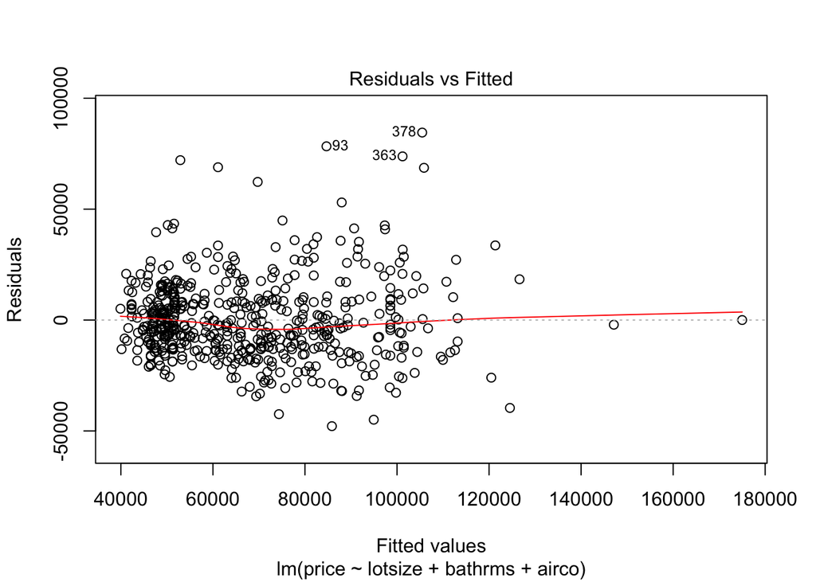

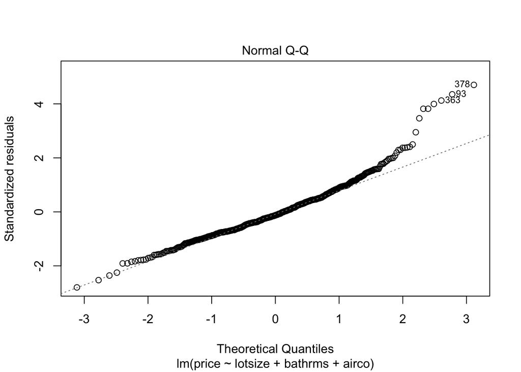

```r
plot(fit.full,c(1,2))
```

The final model doesn’t meet the LINE conditions, specifically the normal Q-Q plot indicates non-normal error. We will use the box cox method to transform price.

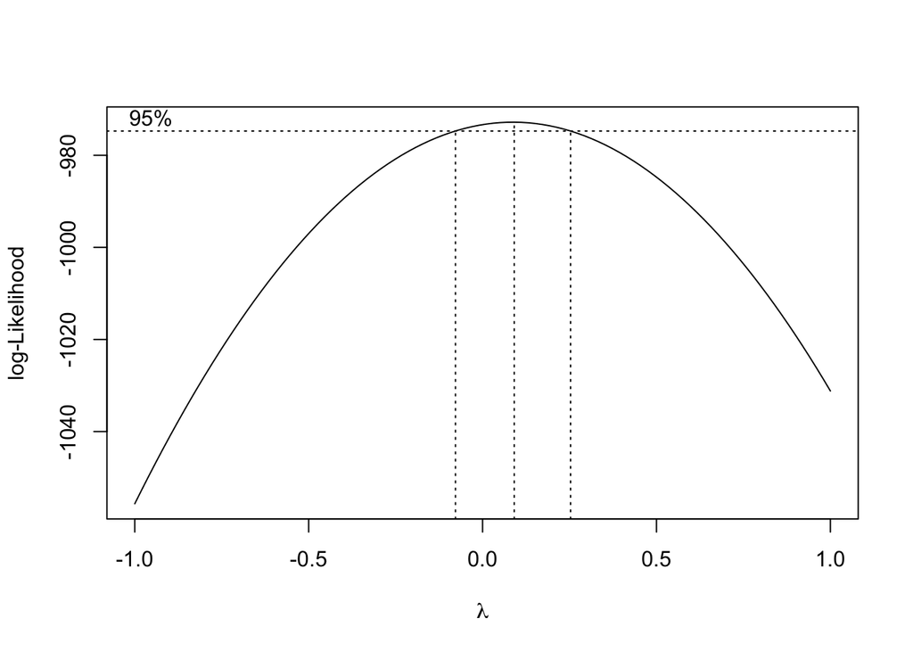

```r
bc<-boxcox(fit.full,lambda=seq(-1,1),length=10)
```

```r
estimate<-bc$x[which.max(bc$y)]
estimate
```

```
## [1] 0.09090909
```

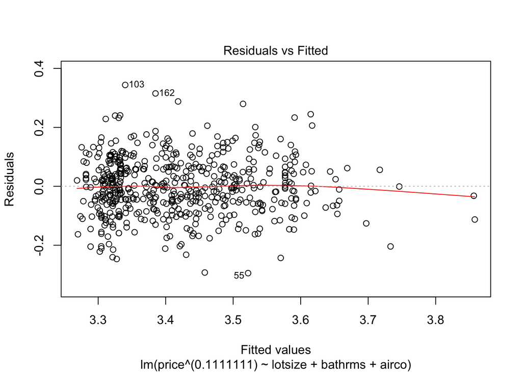

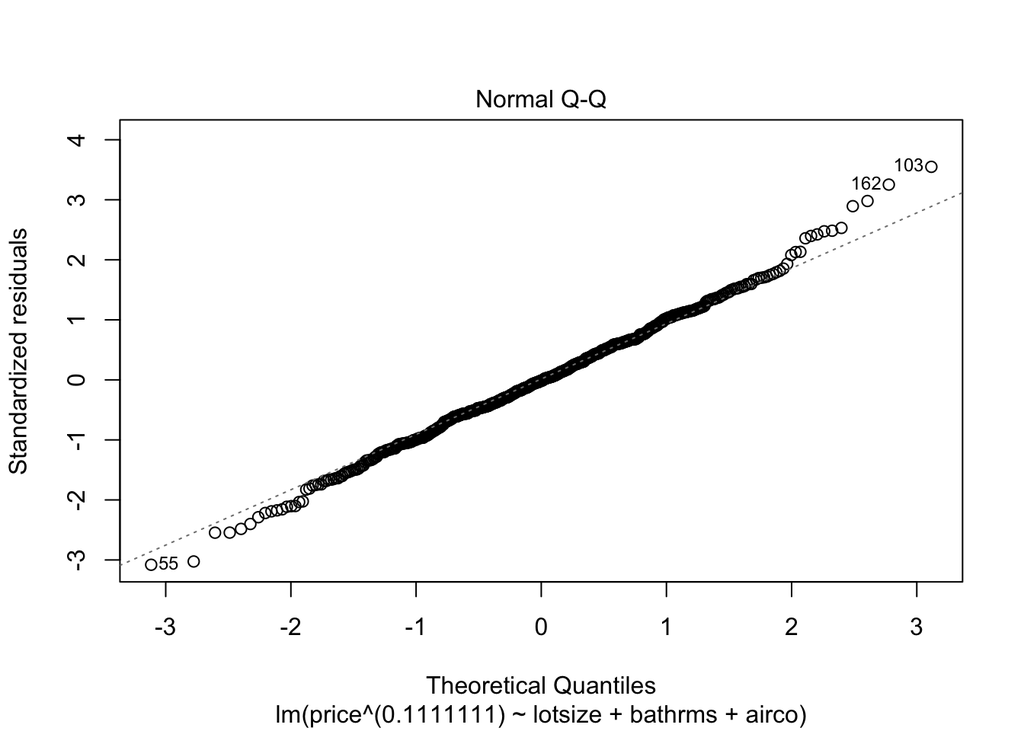

```r
fit.full<-lm(price^(0.1111111)~lotsize+bathrms+airco,data=Housing)
plot(fit.full,c(1,2))
```

[figure not shown]

```r
library(ggplot2)
housingPrediction<-predict(fit.full,Housing)
housingdResid<-housingPrediction-df$price

ggplot(df, aes(x=seq(1, length(df$price)), y=price))+
geom_point(aes(color=abs(housingdResid), size=abs(housingdResid)))+
geom_point(aes(y=housingPrediction), shape=1)+
geom_segment(aes(xend=seq(1, length(df$price)), yend=housingPrediction), alpha=0.2)+
scale_color_continuous(low="orange", high="purple")+
labs(title="Predicted vs Observed Price", x="Index", y="Price", size="| Residuals |")+
theme_bw()+
guides(color = FALSE)
```